# *Natural Language Processing*

## *What is NLP?*

*NLP stands for Natural Language Processing, which is a part of Computer Science, Human language, and Artificial Intelligence. It is the technology that is used by machines to understand, analyse, manipulate, and interpret human's languages. It helps developers to organize knowledge for performing tasks such as translation, automatic summarization, Named Entity Recognition (NER), speech recognition, relationship extraction, and topic segmentation.*

## *Components of NLP*

*There are the following two components of NLP:*

### *Natural Language Understanding (NLU)*

*Natural Language Understanding (NLU) helps the machine to understand and analyse human language by extracting the metadata from content such as concepts, entities, keywords, emotion, relations, and semantic roles.*

*NLU mainly used in Business applications to understand the customer's problem in both spoken and written language.*

*NLU involves the following tasks:*

- *It is used to map the given input into useful representation.*
- *It is used to analyze different aspects of the language.*

### *Natural Language Generation (NLG)*

*Natural Language Generation (NLG) acts as a translator that converts the computerized data into natural language representation. It mainly involves Text planning, Sentence planning, and Text Realization.*

### *Difference between NLU and NLG*

| NLU | NLG |
| --- | --- |
| NLU is the process of reading and interpreting language. | NLG is the process of writing or generating language. |
| It produces non-linguistic outputs from natural language inputs. | It produces constructing natural language outputs from non-linguistic inputs. |

## *Few Applications of NLP*

- *Question Answering*
- *Spam Detection*
- *Sentiment Analysis/Opinion Mining*
- *Machine Translation*
- *Spelling correction*
- *Speech Recognition*
- *Chatbot*
- *Information extraction*
- *Autocomplete*
- *Predictive Typing*
- *Named Entity Recognition*

## *Rule-based NLP vs. Statistical NLP*

*Natural Language Processing is separated in two different approaches:*

### *Rule-based Natural Language Processing*

It uses common sense reasoning for processing tasks. For instance, the freezing temperature can lead to death, or hot coffee can burn people’s skin, along with other common sense reasoning tasks. However, this process can take much time, and it requires manual effort.

### *Statistical Natural Language Processing*

It uses large amounts of data and tries to derive conclusions from it. Statistical NLP uses machine learning algorithms to train NLP models. After successful training on large amounts of data, the trained model will have positive outcomes with deduction.

## *NLP pipeline*

*There are the following steps to build an NLP pipeline:*

### *Sentence Segmentation*

*Sentence Segment is the first step for building the NLP pipeline. It breaks the paragraph into separate sentences.*

*Example: Consider the following paragraph:*

*Independence Day is one of the important festivals for every Indian citizen. It is celebrated on the 15th of August each year ever since India got independence from the British rule. The day celebrates independence in the true sense.*

*Sentence Segment produces the following result:*

- *"Independence Day is one of the important festivals for every Indian citizen."*
- *"It is celebrated on the 15th of August each year ever since India got independence from the British rule."*
- *"This day celebrates independence in the true sense."*

### *Word Tokenization*

*Word Tokenizer is used to break the sentence into separate words or tokens.*

*Example:*

*We are Learning NLP.*

*Word Tokenizer generates the following result:*

*"We", "are", "Learning", "NLP", "."*

### *Stemming*

*Stemming is used to normalize words into its base form or root form. For example, celebrates, celebrated and celebrating, all these words are originated with a single root word "celebrate." The big problem with stemming is that sometimes it produces the root word which may not have any meaning.*

*For Example, intelligence, intelligent, and intelligently, all these words are originated with a single root word "intelligen." In English, the word "intelligen" do not have any meaning.*

### *Lemmatization*

*Lemmatization is quite similar to the Stamming. It is used to group different inflected forms of the word, called Lemma. The main difference between Stemming and lemmatization is that it produces the root word, which has a meaning.*

*For example: In lemmatization, the words intelligence, intelligent, and intelligently has a root word intelligent, which has a meaning.*

### *Identifying Stop Words*

*In English, there are a lot of words that appear very frequently like "is", "and", "the", and "a". NLP pipelines will flag these words as stop words. Stop words might be filtered out before doing any statistical analysis.*

*Example: He is a good boy.*

### *Dependency Parsing*

*Dependency Parsing is used to find that how all the words in the sentence are related to each other.*

### *POS tags*

*POS stands for parts of speech, which includes Noun, verb, adverb, and Adjective. It indicates that how a word functions with its meaning as well as grammatically within the sentences. A word has one or more parts of speech based on the context in which it is used.*

*Example: "Google" something on the Internet.*

*In the above example, Google is used as a verb, although it is a proper noun.*

### *Named Entity Recognition (NER)*

*Named Entity Recognition (NER) is the process of detecting the named entity such as person name, movie name, organization name, or location.*

*Example: Steve Jobs introduced iPhone at the Macworld Conference in San Francisco, California.*

### *Chunking*

*Chunking is used to collect the individual piece of information and grouping them into bigger pieces of sentences.*

## *Phases of NLP*

*There are the following five phases of NLP:*

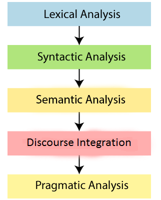

### *Lexical Analysis and Morphological*

*The first phase of NLP is the Lexical Analysis. This phase scans the source code as a stream of characters and converts it into meaningful lexemes. It divides the whole text into paragraphs, sentences, and words.*

### *Syntactic Analysis (Parsing)*

*Syntactic Analysis is used to check grammar, word arrangements, and shows the relationship among the words.*

*Example: Agra goes to the Poonam*

*In the real world, Agra goes to the Poonam, does not make any sense, so this sentence is rejected by the Syntactic analyzer.*

### *Semantic Analysis*

*Semantic analysis is concerned with the meaning representation. It mainly focuses on the literal meaning of words, phrases, and sentences. Sentences such as “hot ice-cream” do not pass.*

### *Discourse Integration*

*Discourse Integration depends upon the sentences that proceeds it and also invokes the meaning of the sentences that follow it. For example: “He works at Google.” In this sentence, “he” must be referenced in the sentence before it.*

### *Pragmatic Analysis*

*Pragmatic is the fifth and last phase of NLP. It helps you to discover the intended effect by applying a set of rules that characterize cooperative dialogues.*

*For Example: "Open the door" is interpreted as a request instead of an order.*

## *Why NLP is difficult?*

*NLP is difficult because Ambiguity and Uncertainty exist in the language.*

### *Ambiguity*

*There are the following three ambiguity:*

#### *Lexical Ambiguity*

*Lexical Ambiguity exists in the presence of two or more possible meanings of the sentence within a single word.*

*Example:*

*Manya is looking for a match.*

*In the above example, the word match refers to that either Manya is looking for a partner or Manya is looking for a match. (Cricket or other match)*

#### *Syntactic Ambiguity*

*Syntactic Ambiguity exists in the presence of two or more possible meanings within the sentence.*

*Example:*

*I saw the girl with the binocular.*

*In the above example, did I have the binoculars? Or did the girl have the binoculars?*

#### *Referential Ambiguity*

*Referential Ambiguity exists when you are referring to something using the pronoun.*

*Example: Kiran went to Sunita. She said, "I am hungry."*

*In the above sentence, you do not know that who is hungry, either Kiran or Sunita.*

### *Pragmatic Ambiguity*

*Such kind of ambiguity refers to the situation where the context of a phrase gives it multiple interpretations. In simple words, we can say that pragmatic ambiguity arises when the statement is not specific.*

*For example, the sentence “I like you too” can have multiple interpretations like I like you (just like you like me), I like you (just like someone else does).*

## *Standard NLP Workflow*

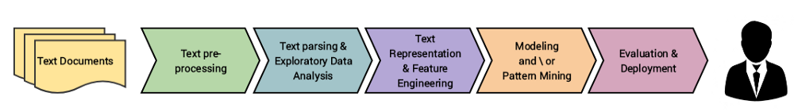

## *NLP Libraries*

[output not shown]

### *NLTK (Natural Language Toolkit)*

*The NLTK Python framework is generally used as an education and research tool. It’s not usually used on production applications. However, it can be used to build exciting programs due to its ease of use.*

*Features*

- *Tokenization.*
- *Part Of Speech tagging (POS).*
- *Named Entity Recognition (NER).*
- *Classification.*
- *Sentiment analysis.*
- *Packages of chatbots.*

*Use-cases*

- *Recommendation systems*
- *Sentiment analysis*
- *Building chatbots*

### *spaCy*

*spaCy is an open-source natural language processing Python library designed to be fast and production-ready. spaCy focuses on providing software for production usage.*

*Features*

- *Tokenization*
- *Part Of Speech tagging (POS)*
- *Named Entity Recognition (NER)*
- *Classification*
- *Sentiment analysis*
- *Dependency parsing*
- *Word vectors*

*Use-cases*

- *Autocomplete and autocorrect*
- *Analyzing reviews*
- *Summarization*

### *Gensim*

*Gensim is an NLP Python framework generally used in topic modeling and similarity detection. It is not a general-purpose NLP library, but it handles tasks assigned to it very well.*

*Features*

- *Latent semantic analysis*
- *Non-negative matrix factorization*
- *TF-IDF*

*Use-cases*

- *Converting documents to vectors*
- *Finding text similarity*
- *Text summarization*

### *Pattern*

*Pattern is an NLP Python framework with straightforward syntax. It’s a powerful tool for scientific and non-scientific tasks. It is highly valuable to students.*

*Features*

- *Tokenization*
- *Part of Speech tagging*
- *Named entity recognition*
- *Parsing*
- *Sentiment analysis*

*Use-cases*

- *Spelling correction*
- *Search engine optimization*
- *Sentiment analysis*

### *TextBlob*

*TextBlob is a Python library designed for processing textual data.*

*Features*

- *Part-of-Speech tagging*
- *Noun phrase extraction*
- *Sentiment analysis*
- *Classification*
- *Language translation*
- *Parsing*
- *Wordnet integration*

*Use-cases*

- *Sentiment Analysis*
- *Spelling Correction*
- *Translation and Language Detection*